# HW1

### Textbook 3.3.1

#### Problem 1. What’s gone wrong with this code? Why are the points not blue?

```
ggplot(data = mpg) +
  geom_point(mapping = aes(x = displ, y = hwy, color = "blue"))
```

모든 점을 blue로 칠하려면 color를 mapping argument 속의 aesthetic으로 사용하면 안되고, color가 하나의 argument가 되어야 한다. 코드를 다음과 같이 작성해야 한다.

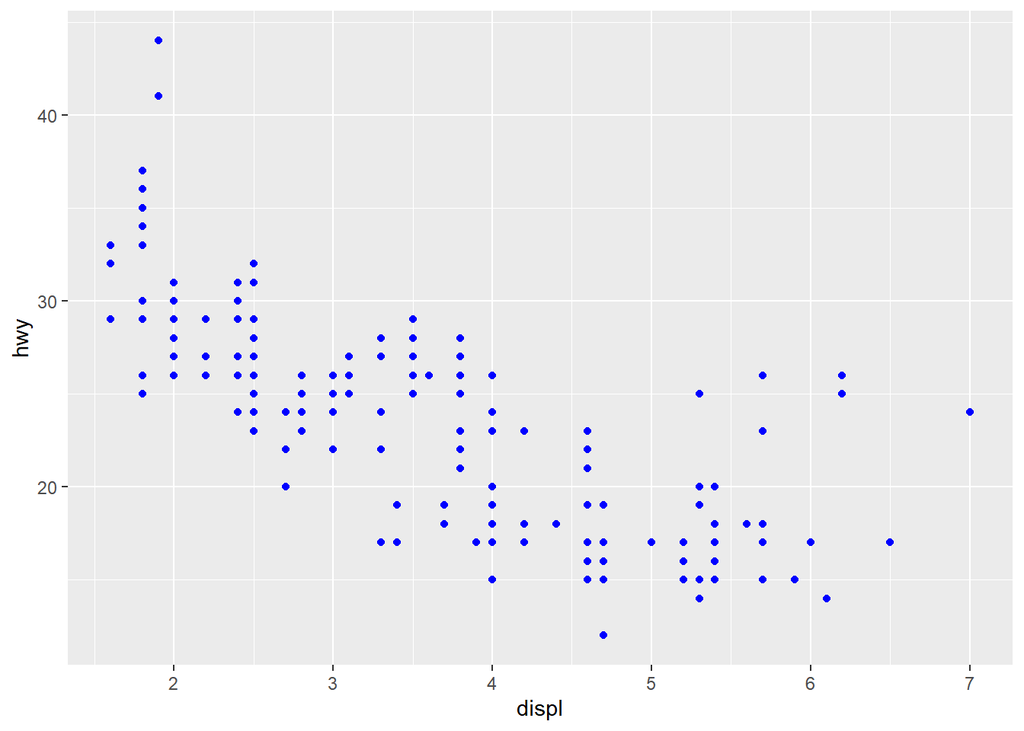

```r
ggplot(data = mpg) +
  geom_point(mapping = aes(x = displ, y = hwy), color = "blue")
```

#### Problem 5. What does the `stroke` aesthetic do? What shapes does it work with? (Hint: use `?geom_point`)

- stroke aesthetic은 plot 상의 점들이 테두리를 가질 때, 테두리(border of point)의 크기를 설정하는 데 사용된다.
- shape 21, 22, 23, 24와 같이 테두리(border)를 가지는 shape를 다룰 때 사용한다.
- 다음과 같이 사용한다.

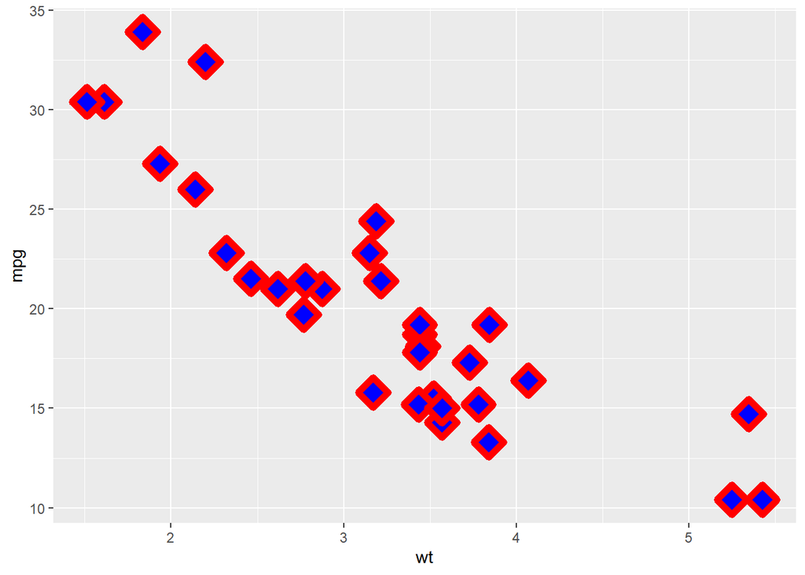

```r
ggplot(mtcars, aes(wt, mpg)) +
  geom_point(shape = 23, colour = "red", fill = "blue", size = 5, stroke = 3)
```

### Textbook 3.5.1

#### Problem 2. What do the empty cells in plot with `facet_grid(drv ~ cyl)` mean? How do they relate to this plot?

```
ggplot(data = mpg) +
  geom_point(mapping = aes(x = drv, y = cyl))
```

다음과 같이 `facet_grid(drv ~ cyl)` 를 포함한 plot을 그린다.

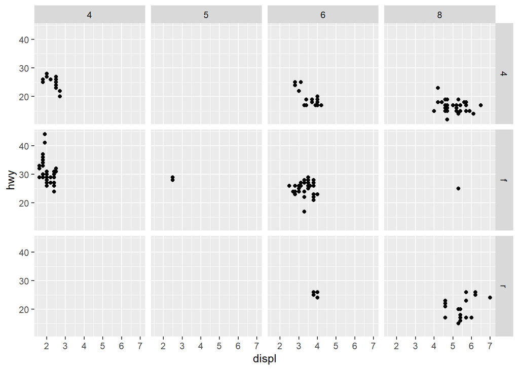

```r
ggplot(data = mpg) +
  geom_point(mapping = aes(x = displ, y = hwy)) +
  facet_grid(drv ~ cyl)
```

여기서 어떤 subplot이 empty cell이라는 것은 해당 subplot에 해당하는 drv, cyl 변수값을 동시에 가지는 데이터가 존재하지 않음을 의미한다.

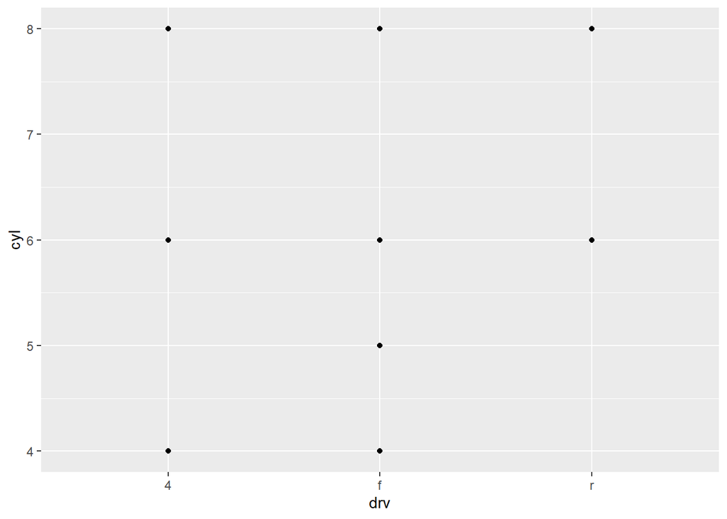

```r
ggplot(data = mpg) +
  geom_point(mapping = aes(x = drv, y = cyl))
```

위의 plot에서 grid를 따라 점이 찍히지 않은 칸이 empty subplot과 대응한다. 단, `cyl = 7`인 subplot은 `facet_grid` 를 포함한 plot에서는 존재하지 않았음을 유의한다.

#### Problem 6. When using `facet_grid()` you should usually put the variable with more unique levels in the columns. Why?

- By putting the variable with more unique levels in the columns, each subplot can have a longer width, maintaining a rectangular shape. It can helps us identify each data, which is indicated by points.

### Textbook 3.6.1

#### Problem 2. Run this code in your head and predict what the output will look like. Then, run the code in R and check your predictions.

```
ggplot(data = mpg, mapping = aes(x = displ, y = hwy, color = drv)) +
  geom_point() +
  geom_smooth(se = FALSE)
```

- `mpg` 데이터에서 `displ` 열이 x축, `hwy` 열이 y축이 되는 scatterplot이 그려질 것이며, 각 레코드의 `drv` 값에 따라 점의 색깔이 다를 것이다. 또한, 데이터의 전체적인 추이를 보여주는 회귀선이 그려질 것이며, 신뢰구간(confidence interval)은 나타나지 않을 것이다.
- Let’s check my prediction.

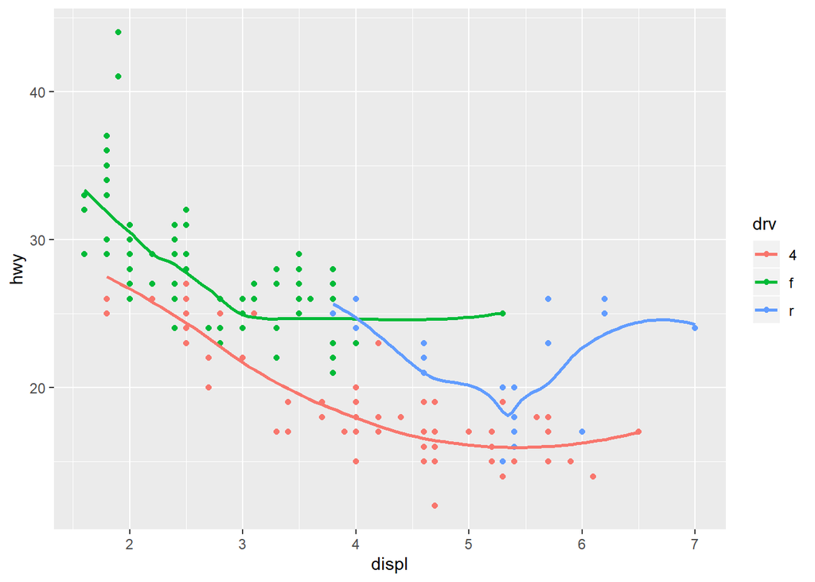

```r
ggplot(data = mpg, mapping = aes(x = displ, y = hwy, color = drv)) +
  geom_point() +
  geom_smooth(se = FALSE)
```

- 예상과 조금 달랐던 점은, `drv` 값에 따라 점의 색깔이 다를 뿐만 아니라, 회귀선까지 `drv` 값을 기준으로 구분하여 따로 그려졌다는 것이다.

#### Problem 6. Recreate the R code necessary to generate the following graphs.

- 좌측 상단의 그래프부터 오른쪽으로 이동하면서 (1) ~ (6) 으로 칭하겠다.

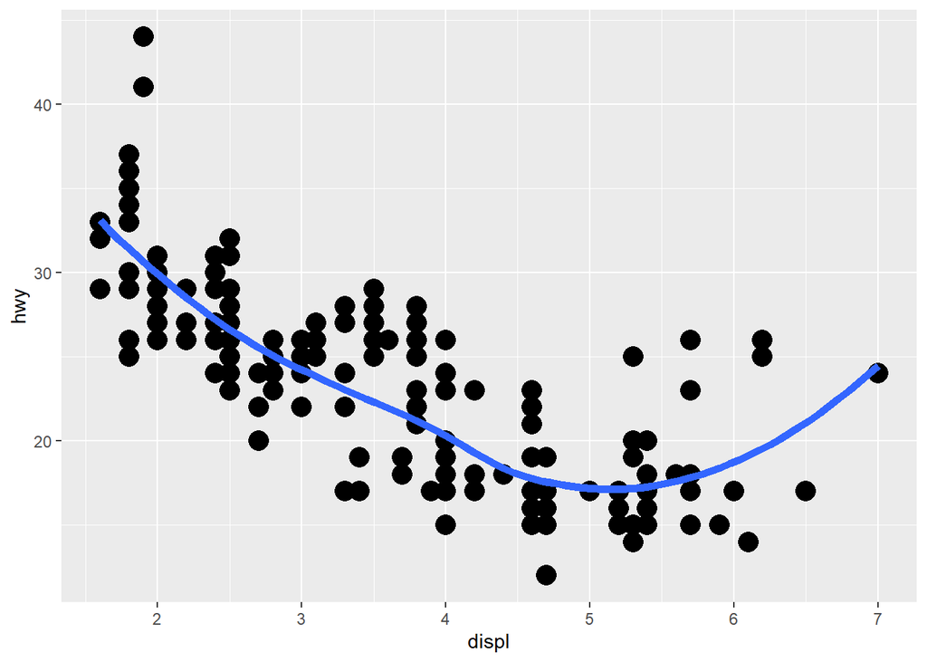

```r
ggplot(data = mpg, mapping = aes(x = displ, y = hwy)) +
  geom_point(size = 5)+
  geom_smooth(se = FALSE, size = 2)
```

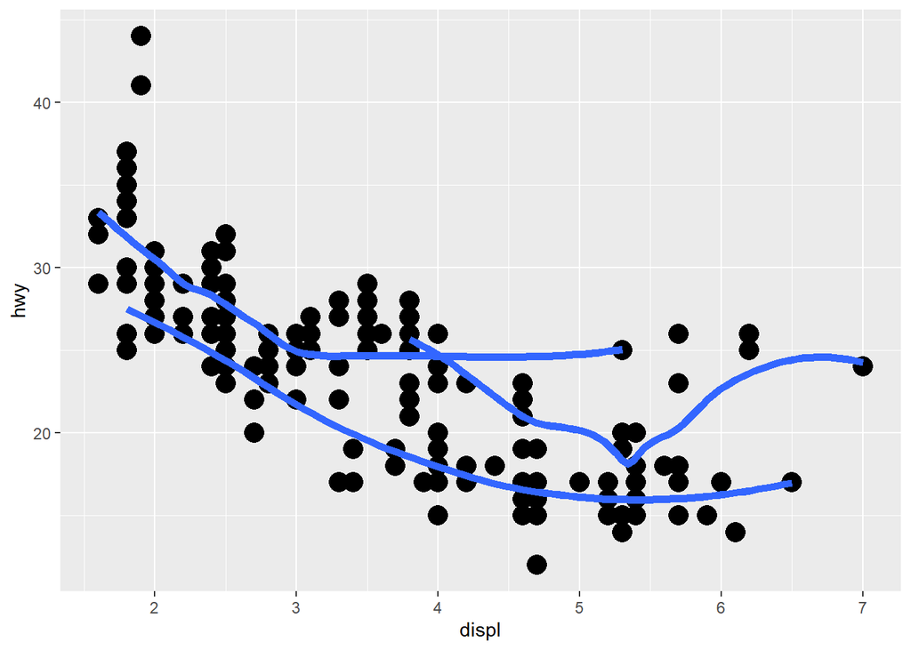

```r
ggplot(data = mpg, mapping = aes(x = displ, y = hwy)) +
  geom_point(size = 5)+
  geom_smooth(mapping = aes(group = drv), se = FALSE, size = 2)
```

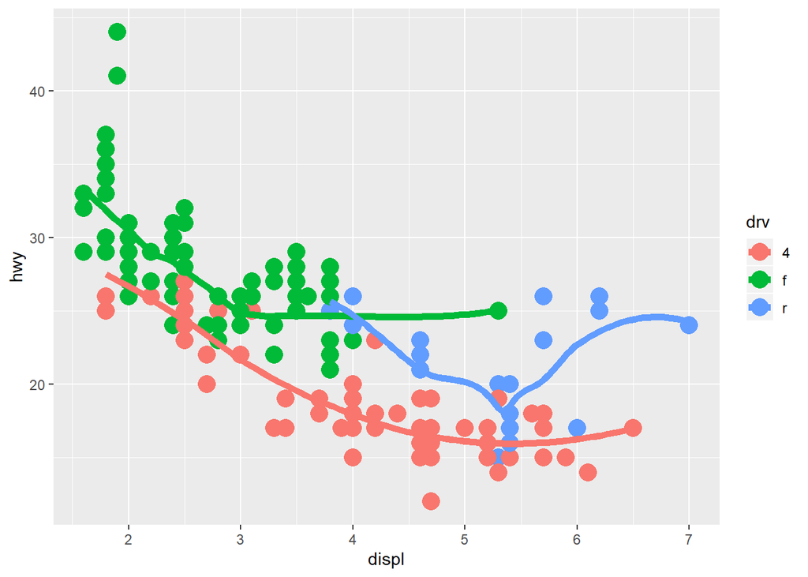

```r
ggplot(data = mpg, mapping = aes(x = displ, y = hwy, color = drv)) +
  geom_point(size = 5)+
  geom_smooth(se = FALSE, size = 2)
```

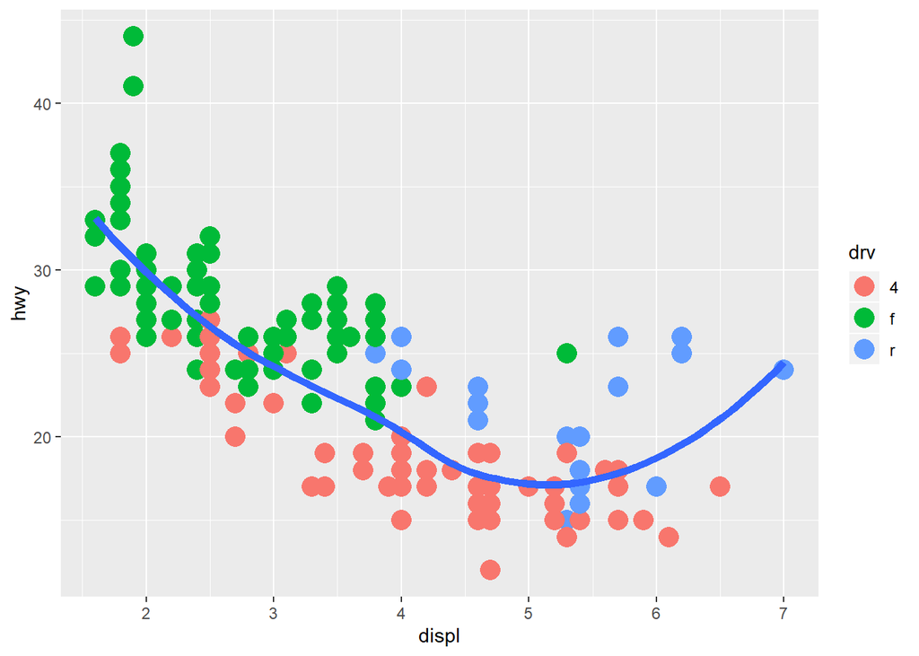

```r
ggplot(data = mpg, mapping = aes(x = displ, y = hwy)) +
  geom_point(mapping = aes(color = drv), size = 5)+
  geom_smooth(se = FALSE, size = 2)
```

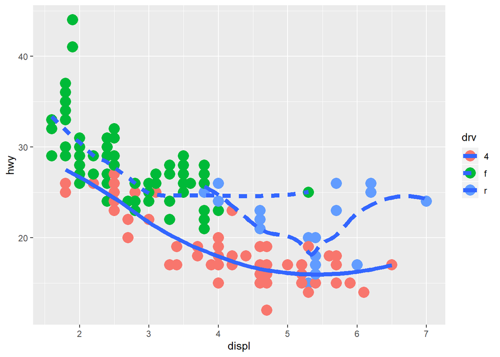

```r
ggplot(data = mpg, mapping = aes(x = displ, y = hwy)) +
  geom_point(mapping = aes(color = drv), size = 5)+
  geom_smooth(mapping = aes(linetype = drv), se = FALSE, size = 2)
```

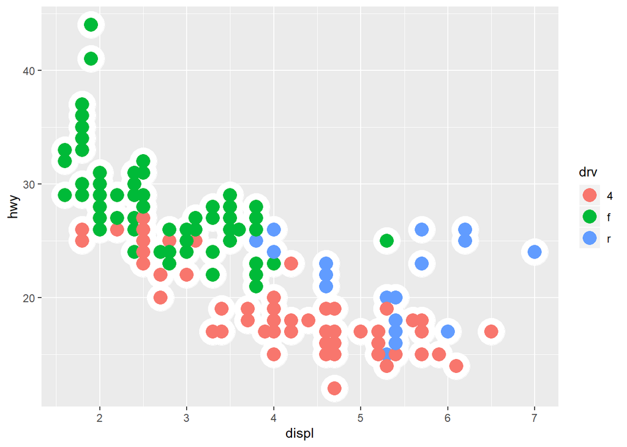

```r
ggplot(data = mpg, mapping = aes(x = displ, y = hwy)) +
  geom_point(color = 'white', size = 10) +
  geom_point(mapping = aes(color = drv), size = 5)
```

### Textbook 3.7.1

#### Problem 1. What is the default geom associated with `stat_summary()`? How could you rewrite the previous plot to use that geom function instead of the stat function?

- `geom_pointrange()` is the default geom associated with `stat_summary()`.
- This code using `geom_pointrange()` can produce the previous plot (in the problem).

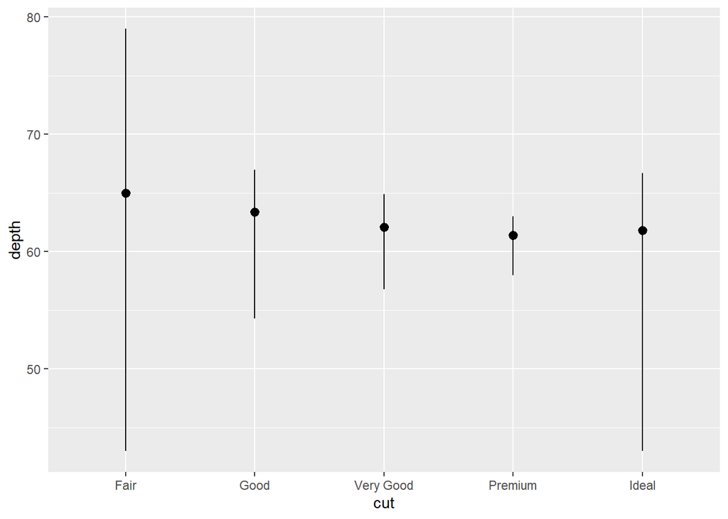

```r
ggplot(data = diamonds) +
  geom_pointrange(mapping = aes(x = cut, y = depth), stat = 'summary', fun.ymin = min, fun.ymax = max, fun.y = median)
```

#### Problem 5. In our proportion bar chart, we need to set `group = 1`. Why?

- If we don’t set `group = 1`, the data is automatically grouped by `cut`, so the proportion of each `cut` value in the same `cut` category is always 1.
- By setting `group = 1`, we can consider all levels of `cut` together, making the proper proportion of each level come out on the vertical axis.

#### In other words what is the problem with these two graphs?

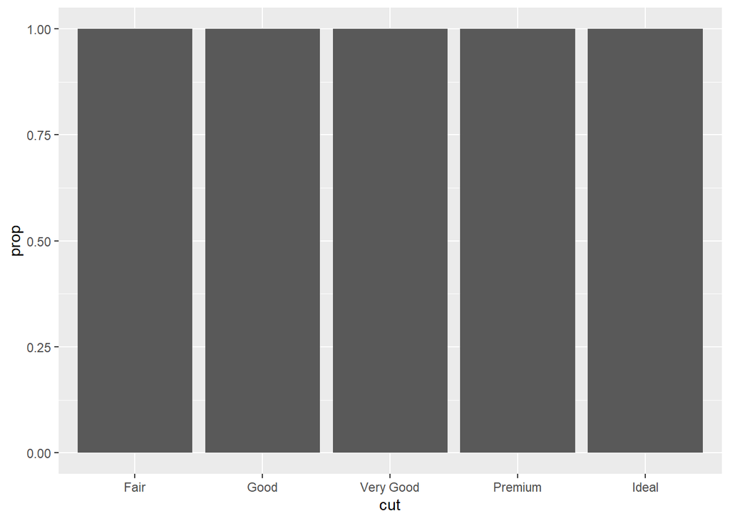

```r
ggplot(data = diamonds) +
  geom_bar(mapping = aes(x = cut, y = ..prop..))
```

For example, the proportion of Fair in the Fair `cut` level is definitely 1. So every `cut` level has a proportion of 1. This code produces a proportion bar chart.

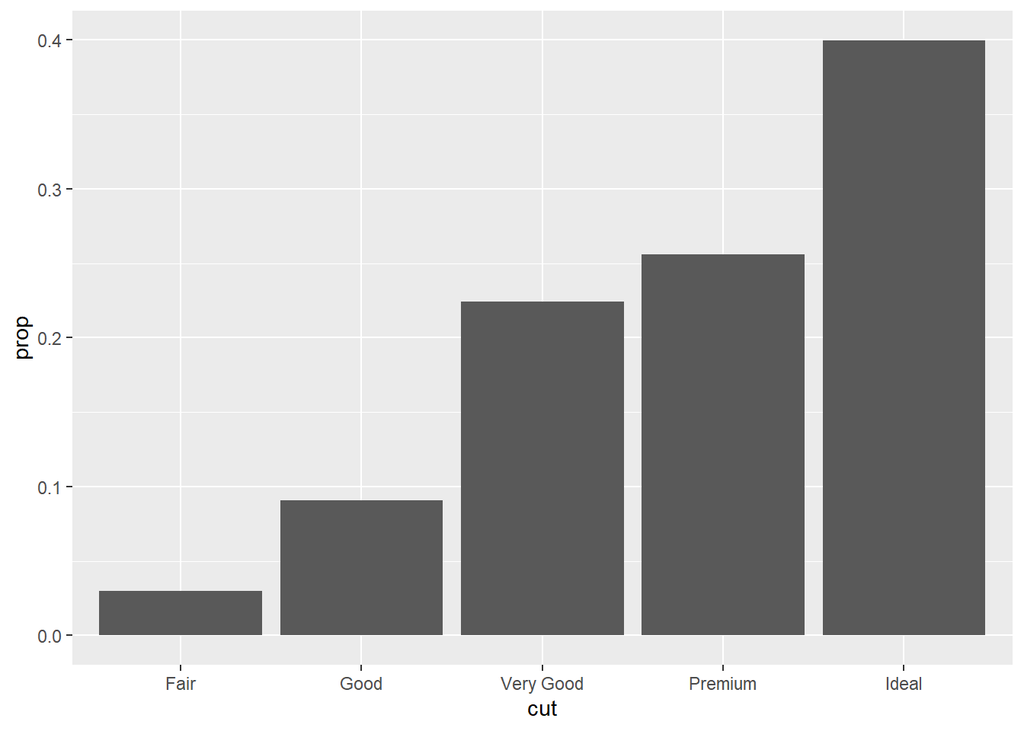

```r
ggplot(data = diamonds) +
  geom_bar(mapping = aes(x = cut, y = ..prop.., group = 1))
```

- Let take a look at the second one.

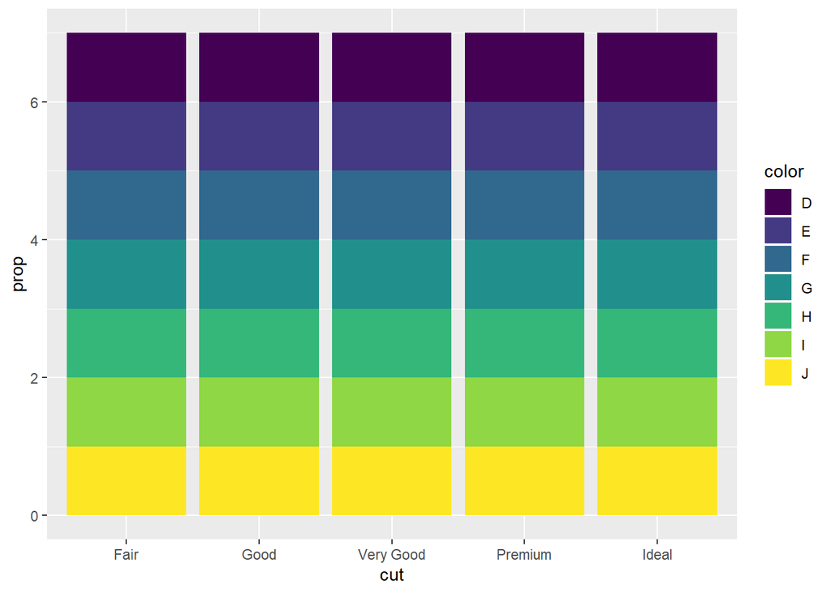

```r
ggplot(data = diamonds) +
  geom_bar(mapping = aes(x = cut, fill = color, y = ..prop..))
```

In this graph, the data gets grouped by `cut` levels, and also `color` levels. Having `y = ..prop..` after those aesthetics causes the problem. For example, the proportion of Fair & D color, in the Fair and D `cut` and `color` level is definitely 1. This applies for every case. So for each `cut` level, 7 `color` levels each containing a proportion of 1 are stacked, making every bar have a height of 7. This code produces the bar chart we wanted.

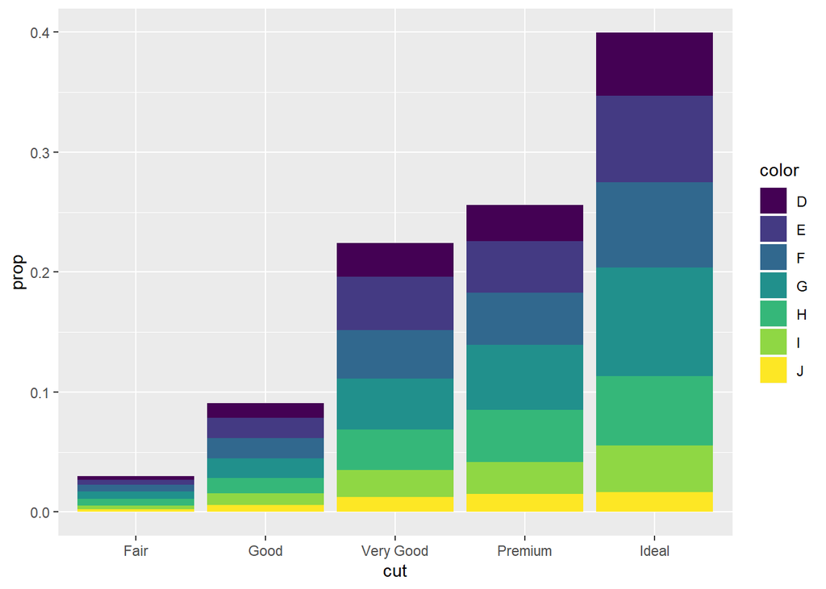

```r
ggplot(data = diamonds) +
  geom_bar(mapping = aes(x = cut, fill = color, y = ..count../dim(diamonds)[1]))+
  labs(y = "prop")
```

### Textbook 3.8.1

#### Problem 1. What is the problem with this plot? How could you improve it?

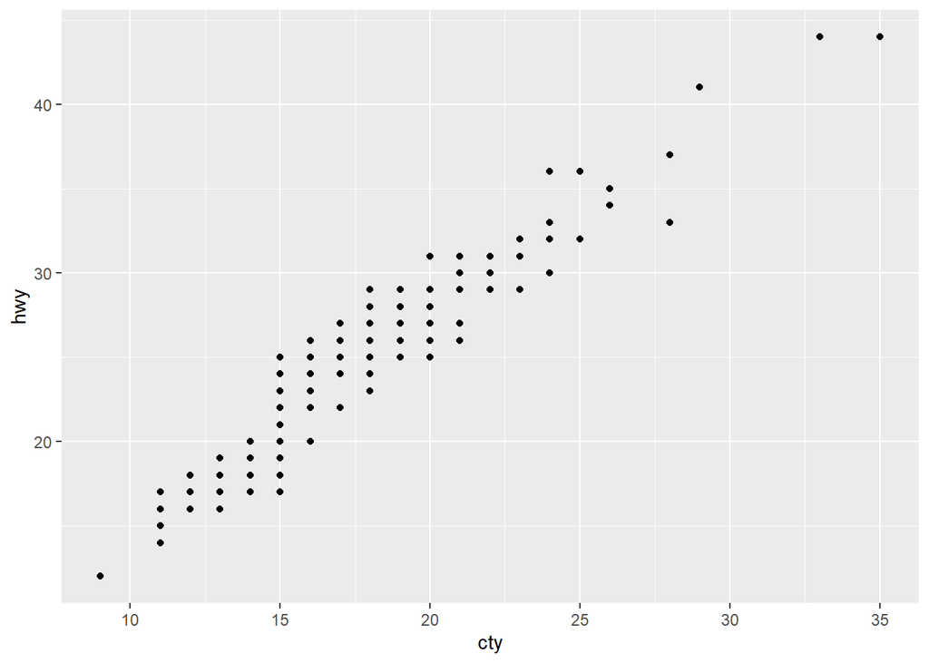

```r
ggplot(data = mpg, mapping = aes(x = cty, y = hwy)) +
  geom_point()
```

- In the data, the values of `cty` and `hwy` are rounded so many points are overlapped (overplotting problem). We can’t see where the mass of data is.
- We can improve this problem by setting the position adjustment to `jitter`.

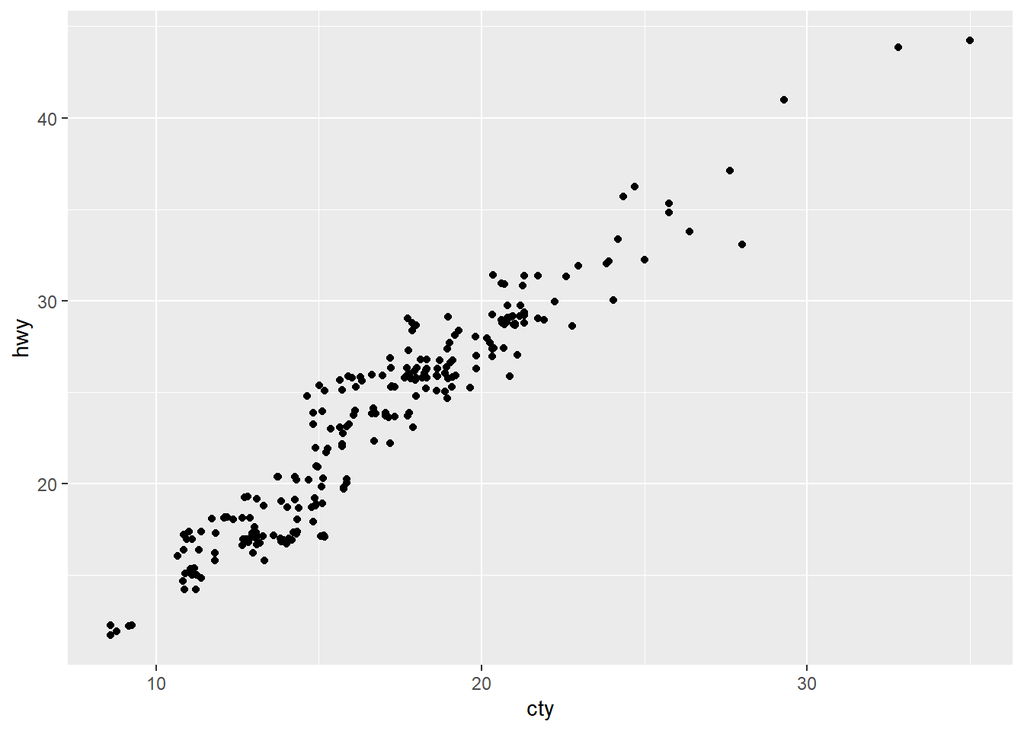

```r
ggplot(data = mpg, mapping = aes(x = cty, y = hwy)) +
  geom_point(position = "jitter")
```

- This makes us know which part of the scatterplot contains more data.

#### Problem 3. Compare and contrast `geom_jitter()` with `geom_count()`.

- They both let us notice where the data is concentrated on the scatterplot.
- `geom_jitter()` gives a small random noise to each original data, and then plots the adjusted data.
- `geom_count()` deals with the original data, but the size of the point is determined by the count of that point.

### Textbook 3.9.1

#### Problem 1. Turn a stacked bar chart into a pie chart using `coord_polar()`.

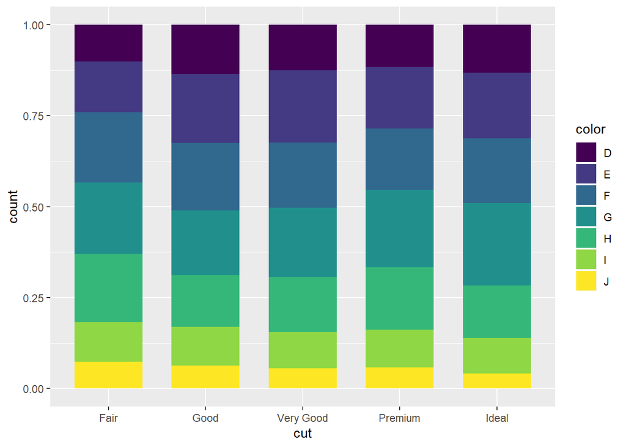

```r
bar <- ggplot(data = diamonds) +
  geom_bar(mapping = aes(x = cut, fill = color), position = "fill", width = 0.7)
bar
```

This is a stacked bar chart using the data `diamonds`. With the code below, we can change this into a pie chart that shows the proportions of `color` levels in each `cut` level.

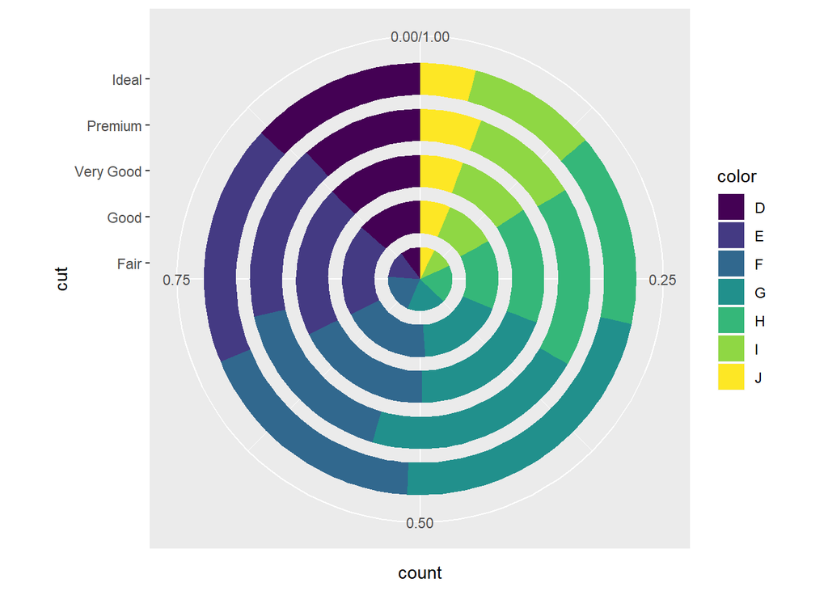

```r
bar + coord_polar("y")
```

#### Problem 4. What does the plot below tell you about the relationship between city and highway mpg? Why is `coord_fixed()` important? What does `geom_abline()` do?

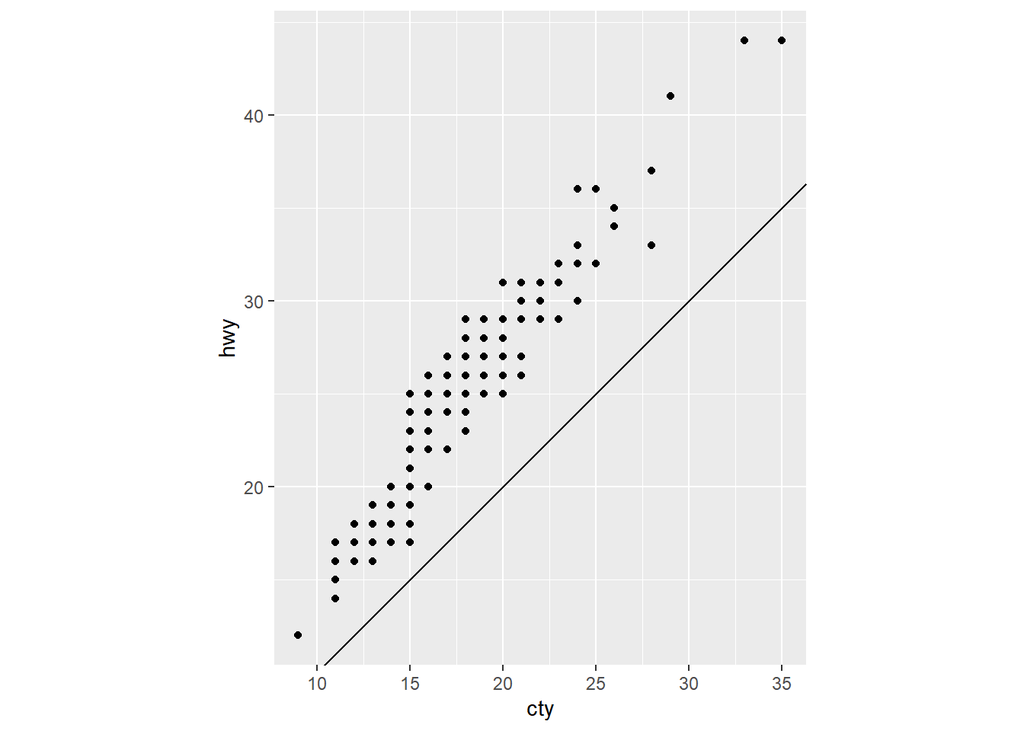

```r
ggplot(data = mpg, mapping = aes(x = cty, y = hwy)) +
  geom_point() +
  geom_abline() +
  coord_fixed()
```

- Every point is above the line drawn by `geom_abline()`. We can conclude that highway mpg is always higher than city mpg.
- We need `coord_fixed()` in order to set the ratio between the horizontal and vertical intervals. Without any arguments, `coord_fixed()` makes the ratio to be 1:1.
- `geom_abline()` draws a straight line, and we can set the intercept and slope of the line. Without any arguments, which is this case, `intercept = 0` and `slope = 1`.

### Textbook 6.3

#### Problem 2. What other common mistakes will RStudio diagnostics report?

- When we use functions, RStudio detects missing arguments and report them.
- It warns if the variable used has never been defined.
- It warns if a variable was defined, but has never been used.

### Textbook 28.2.1

#### Problem 1. Create one plot on the fuel economy data with customised `title`, `subtitle`, `caption`, `x`, `y`, and `colour` labels.

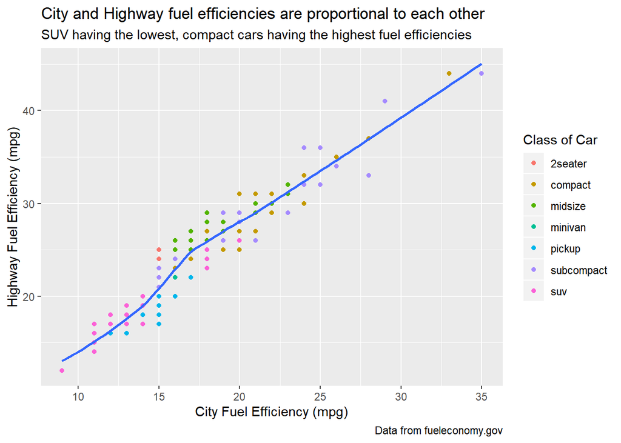

```r
ggplot(data = mpg, mapping = aes(x = cty, y = hwy)) +
  geom_point(mapping = aes(color = class)) +
  geom_smooth(se = FALSE) +
  labs(title = "City and Highway fuel efficiencies are proportional to each other",
       subtitle = "SUV having the lowest, compact cars having the highest fuel efficiencies",
       caption = "Data from fueleconomy.gov",
       x = "City Fuel Efficiency (mpg)",
       y = "Highway Fuel Efficiency (mpg)",
       color = "Class of Car")
```

### Textbook 28.4.4

#### Problem 4. Use `override.aes` to make the legend on the following plot easier to see.

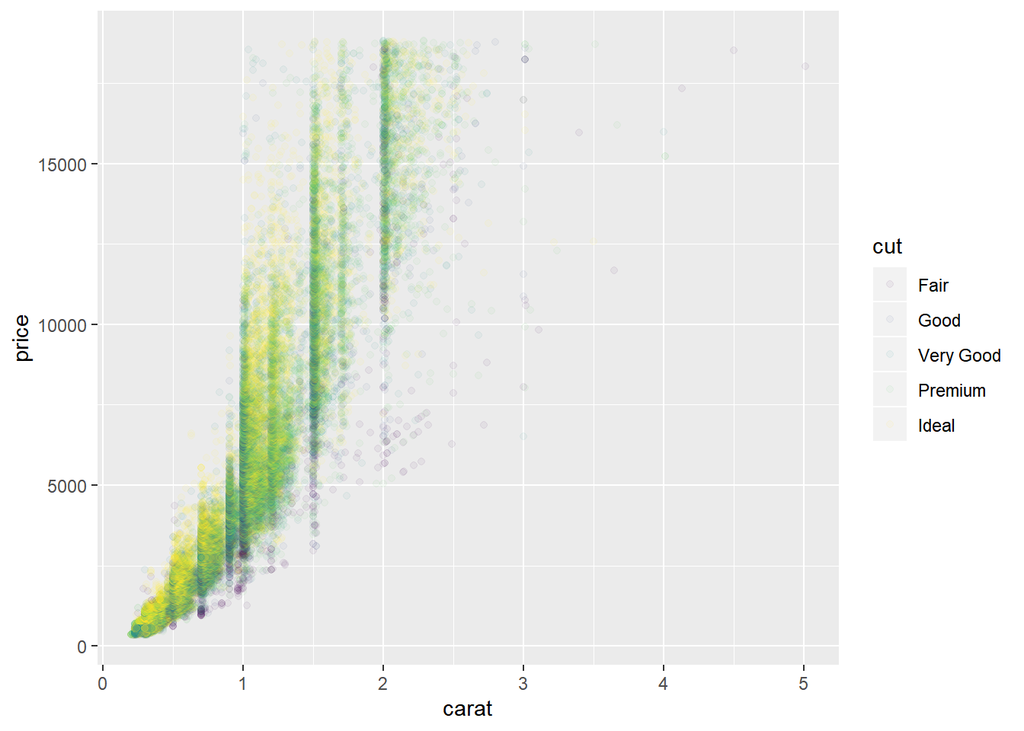

```r
ggplot(diamonds, aes(carat, price)) +
  geom_point(aes(colour = cut), alpha = 1/20)
```

Using `guides()` along with `guide_legend()` and `override.aes`, we can adjust the `alpha` setting only for the legend on the plot.

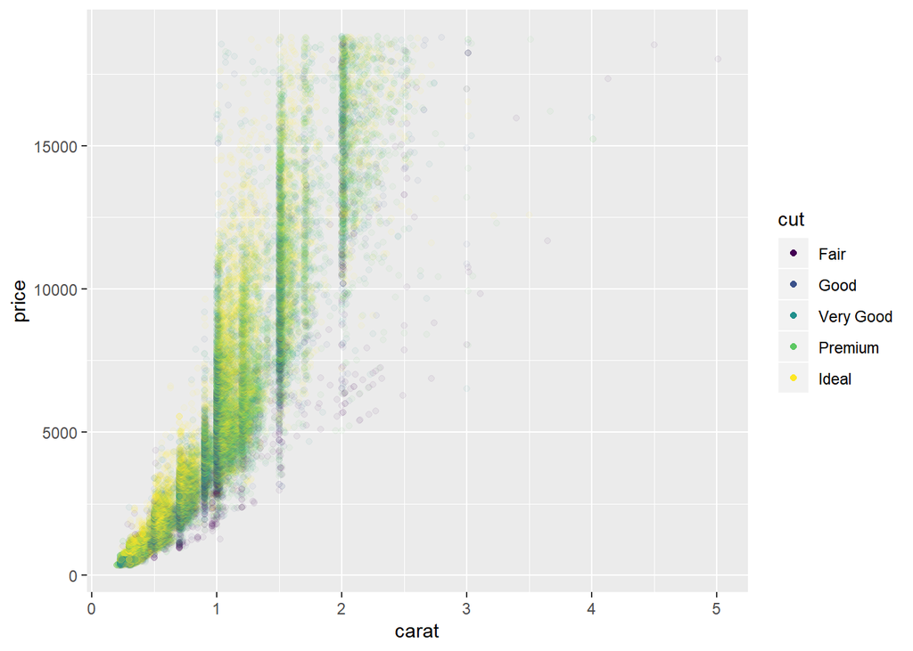

```r
ggplot(diamonds, aes(carat, price)) +
  geom_point(aes(colour = cut), alpha = 1/20) +
  guides(color = guide_legend(override.aes = list(alpha = 1)))
```

### Extra Questions

#### Problem 1. Write an R script that when run performs the following:

#### (a)

```r
x <- 5
y <- 6
```

- Nothing appears. Variables are only assigned.

#### (b)

```r
log(x + y)
```

```
## [1] 2.397895
```

#### (c)

```r
log10(x * y /2)
```

```
## [1] 1.176091
```

#### (d)

```r
x^(1/3) + 2 * y^(1/4)
```

```
## [1] 4.840145
```

#### (e)

```r
10^(x-y) + exp(1)^(x+y)
```

```
## [1] 59874.24
```

#### Problem 2. Why does the following code not work?

```
my_variable <- 123
my_varlable
```

- We have assigned 123 to a variable named `my_variable`. The next line asked for a variable named `my_varlable`, but we have never defined that variable.
- This code works normally.

```r
my_variable <- 123
my_variable
```

```
## [1] 123
```